# Cyclistic Project

Fernando Hernández Esquivel

2022-09-14

# ESCENARIO

Eres un analista de datos júnior que trabaja en el equipo de analistas de marketing de Cyclistic, una empresa de bicicletas compartidas de Chicago. La directora de marketing cree que el éxito futuro de la empresa depende de maximizar la cantidad de membresías anuales. Por lo tanto, tu equipo quiere entender qué diferencias existen en el uso de las bicicletas Cyclistic entre los ciclistas ocasionales y los miembros anuales. A través de estos conocimientos, tu equipo diseñará una nueva estrategia de marketing para convertir a los ciclistas ocasionales en miembros anuales. Sin embargo, antes de eso, los ejecutivos de Cyclistic deben aprobar tus recomendaciones; por eso, debes respaldar tu propuesta con una visión convincente de los datos y visualizaciones profesionales de los mismos.

# PERSONAJES Y EQUIPO

- Cyclistic: Un programa de bicicletas compartidas que incluye 5,800 bicicletas y 600 estaciones. Cyclistic se destaca por ofrecer también bicicletas reclinadas, triciclos manuales y bicicletas de carga que ofrecen un uso más inclusivo de las bicicletas compartidas para las personas con discapacidad y los ciclistas que no pueden utilizar una bicicleta estándar de dos ruedas. La mayoría de los ciclistas eligen las bicicletas tradicionales, alrededor de un 8% de los ciclistas usan las opciones asistidas. Los usuarios de Cyclistic son más propensos a utilizar la bicicleta para recreación, pero alrededor del 30% la utiliza para ir al trabajo cada día.
- Lily Moreno: La directora de marketing y tu gerente. Moreno es responsable del desarrollo de campañas e iniciativas para promover el programa de bicicletas compartidas. Las campañas pueden incluir correo electrónico, redes sociales y otros canales.
- Equipo de análisis computacional de datos de marketing de Cyclistic: Un equipo de analistas de datos que se encargan de recopilar, analizar e informar datos que ayudan a conducir la estrategia de marketing de Cyclistic. Te incorporaste a este equipo hace seis meses y te has dedicado no solo a conocer la misión y las metas de negocios de Cyclistic, sino también a ver cómo puedes ayudar a Cyclistic a lograrlo, desde tu posición de analista de datos júnior.
- Equipo ejecutivo de Cyclistic: El equipo ejecutivo, sumamente detallista, decidirá si aprueba el programa de marketing recomendado.

# LA EMPRESA

En 2016, Cyclistic lanzó una exitosa oferta de bicicletas compartidas. Desde entonces, el programa creció hasta alcanzar una flota de 5,824 bicicletas georreferenciadas y bloqueadas en una red de 692 estaciones en toda Chicago. Las bicicletas se pueden desbloquear desde una estación y devolverse en cualquier otra estación del sistema en cualquier momento.  
Hasta ahora, la estrategia de marketing de Cyclistic se basaba en la construcción de un reconocimiento de marca general y en atraer a amplios segmentos de consumidores. Uno de los enfoques que ayudó a hacer esto posible fue la flexibilidad de sus planes de precios: pases de un solo viaje, pases de un día completo y membresías anuales. A los clientes que compran pases de un solo viaje o pases de un día completo se los llama ciclistas ocasionales. Los clientes que compran membresías anuales se llaman miembros de Cyclistic.  
Los analistas financieros de Cyclistic llegaron a la conclusión de que los miembros anuales son mucho más rentables que los ciclistas ocasionales. Aunque la flexibilidad de precios ayuda a Cyclistic a atraer más clientes, Moreno cree que maximizar el número de miembros anuales será clave para el crecimiento futuro. En lugar de crear una campaña de marketing que apunte a todos los clientes nuevos, Moreno cree que hay muchas posibilidades de convertir a los ciclistas ocasionales en miembros. Ella señala que los ciclistas ocasionales ya conocen el programa de Cyclistic y han elegido a Cyclistic para sus necesidades de movilidad.  
Moreno estableció una meta clara: Diseñar estrategias de marketing orientadas a convertir a los ciclistas ocasionales en miembros anuales. Sin embargo, para hacer eso, el equipo de analistas de marketing necesita entender mejor cómo difieren los miembros anuales y los ciclistas ocasionales, por qué los ciclistas ocasionales comprarían una membresía y cómo los medios digitales podrían afectar sus tácticas de marketing. Moreno y su equipo están interesados en analizar los datos históricos de viajes en bicicleta de Cyclistic para identificar tendencias.

# LAS PREGUNTAS A RESPONDER

- 1.¿En qué se diferencian los socios anuales y los ciclistas ocasionales con respecto al uso de las bicicletas de Cyclistic?
- 2.¿Por qué los ciclistas ocasionales comprarían membresías anuales de Cyclistic?
- 3.¿Cómo puede usar Cyclistic los medios digitales para influenciar a los ciclistas ocasionales a convertirse en miembros?

# INFORME

## 1.-PREGUNTAR

### Una instrucción clara de la tarea empresarial

● ¿Cuál es el problema que intentas resolver?  
El problema que se intenta resolver es el de aumentar la cantidad de ciclistas que pertenezcan a la categoría de socios y dejen de ser ciclistas ocasionales.

● ¿Cómo tus conocimientos pueden impulsar las decisiones empresariales?  
Mis conocimientos pueden impulsar las decisiones empresariales a través del análisis, encontrando información que sea relevante para la solución de problemas basada en datos.

#### TAREA EMPRESARIAL

**Encontrar las caracteristicas de los ciclistas socios y ocasionales, que nos permitan comprender qué ha llevado a los ciclistas ser socios para que de igual forma los ciclistas ocasionales se conviertan en socios.**

## 2.-PREPARAR

### Una descripción de todas las fuentes de datos utilizadas

● ¿Dónde se ubican tus datos?  
Los datos se ubican en el sitio de la empresa que almacena los datos cada lapso de tiempo, el link para su descarga es el siguiente [link.](https://divvy-tripdata.s3.amazonaws.com/index.html)

● ¿Cómo están organizados los datos?  
Los datos están organizados por meses, y se han guardado en archivos de extensión .csv.

● ¿Hay problemas con el sesgo o la credibilidad de estos datos? ¿Tus datos son confiables, originales, integrales, actuales y citados (ROCCC)?  
No existen sesgos de ningun tipo en los datos, todos los datos son confiables, originales, integrales, actuales y citados.

● ¿Cómo estás abordando la autorización, la privacidad, la seguridad y la accesibilidad?  
Los datos han sido proporcionados por Motivate International Inc. bajo la siguiente [licencia.](https://ride.divvybikes.com/data-license-agreement)

● ¿Cómo verificaste la integridad de los datos?  
La integridad de los datos se verificó con el programa estadístico R.

● ¿De qué manera te ayuda a responder tu pregunta?  
El hecho de que los datos sean confiables, integrales y actuales, indica que se puede obtener información valiosa de los datos y de esta manera responder nuestra pregunta de negocio.

● ¿Existe algún problema con los datos? Existe un número considerable de observaciones con valores NA en las variables: start_station_name, start_station_id, end_station_name, start_station_id.

## 3.-PROCESAR

### Documentación de todas las limpiezas y manipulaciones de datos

● ¿Qué herramientas eliges y por qué?  
Se eligió el programa estadístico R por el poder de análisis y la versatilidad del mismo.

● ¿Has garantizado la integridad de los datos?  
Sí, se ha garantizado la integridad de los datos.

● ¿Qué pasos seguiste para garantizar que tus datos están limpios?  
Se revisó por variable si existian valores nulos o si los valores no eran congruentes y lógicos.

● ¿Cómo puedes verificar que tus datos están limpios y listos para analizar?  
En el programa R a través de funciones que nos ayudan a encontrar valores nulos o no deseados, y que carecen de congruncia en el análisis.

● ¿Documentaste tu proceso de limpieza para poder revisar y compartir estos resultados?  
Sí, se ha documentado todo el proceso desde la descarga de los archivos hasta la creación de gráficos.

#### DOCUMENTACIÓN

Documentación de Procesamiento de datos.  
Realizado por Fernando Hernández Esquivel  
Fecha: 15-09-2022

1.-Descargar los archivos de los últimos 12 meses para su limpieza y análisis, del siguiente link: https://divvy-tripdata.s3.amazonaws.com/index.html  
2.-Descomprime los archivos.  
3.-Guarda los archivos en la carpeta destinada al proyecto.  
4.-Cambia el nombre de los archivos para una mejor manipulación.  
ejemplo: 202208-divvy-tripdata.csv por 2022_08.csv.  
5.-Abrir el programa estadístico R.  
6.-Crear un nuevo documento ya sea Script o Rmarkdown.  
7.-Cargar la librería tidyverse, en caso de no tener descargada la librería, descargarla con el siguiente código: install.packages(“tidyverse”).  
8.-Carga los archivos extensión .csv.  
9.-Une los documentos en un nuevo dataframe.  
10.-Revisa la estructura de los datos.  
11.-Crea una columna que se llame “ride_length”. Calcula la extensión de cada viaje restando la columna “started_at” de la columna “ended_at”.  
12.-Crea una columna llamada “day_of_week” y calcula el día de la semana en el que empezó cada viaje.  
13.-Retirar las observaciones que en la variable start_station_name = “HQ QR” y en la variable ride_length < 0.  
14.-Revisa los valores nulos por columna.  
15.-Elimina los valores nulos del dataframe.  
16.-Cambiar el tipo de dato a factor de las variables: rideable_type, member_casual, day_of_week.  
17.-Realizar análisis descriptivo.  
18.-Agregar el resumen del análisis.  
18.-Crear 2 archivos .csv con los resultados de las consultas para uso externo.  
19.-Realizar gráficos con la paquetería ggplot2.  
20.-Agregar las 3 recomendaciones al informe.  
21.-Guardar el archivo Rmarkdown.  
22.-Agregar la documentación al código

```r
library(tidyverse)
```

```r
sep_21<- read_csv("/Users/fernandohernandezesquivel/Desktop/Google certification/2021_09.csv")
oct_21<- read_csv("/Users/fernandohernandezesquivel/Desktop/Google certification/2021_10.csv")
nov_21<- read_csv("/Users/fernandohernandezesquivel/Desktop/Google certification/2021_11.csv")
dic_21<- read_csv("/Users/fernandohernandezesquivel/Desktop/Google certification/2021_12.csv")
ene_22<- read_csv("/Users/fernandohernandezesquivel/Desktop/Google certification/2022_01.csv")
feb_22<- read_csv("/Users/fernandohernandezesquivel/Desktop/Google certification/2022_02.csv")
mar_22<- read_csv("/Users/fernandohernandezesquivel/Desktop/Google certification/2022_03.csv")
abr_22<- read_csv("/Users/fernandohernandezesquivel/Desktop/Google certification/2022_04.csv")
may_22<- read_csv("/Users/fernandohernandezesquivel/Desktop/Google certification/2022_05.csv")
jun_22<- read_csv("/Users/fernandohernandezesquivel/Desktop/Google certification/2022_06.csv")
jul_22<- read_csv("/Users/fernandohernandezesquivel/Desktop/Google certification/2022_07.csv")
ago_22<- read_csv("/Users/fernandohernandezesquivel/Desktop/Google certification/2022_08.csv")
```

```r
df <- rbind(sep_21,oct_21,nov_21,dic_21,ene_22,feb_22,mar_22,abr_22,may_22,jun_22,jul_22,ago_22)
```

```r
glimpse(df)
```

```
## Rows: 5,883,043
## Columns: 13
## $ ride_id            <chr> "9DC7B962304CBFD8", "F930E2C6872D6B32", "6EF7213790…
## $ rideable_type      <chr> "electric_bike", "electric_bike", "electric_bike", …
## $ started_at         <dttm> 2021-09-28 16:07:10, 2021-09-28 14:24:51, 2021-09-…
## $ ended_at           <dttm> 2021-09-28 16:09:54, 2021-09-28 14:40:05, 2021-09-…
## $ start_station_name <chr> NA, NA, NA, NA, NA, NA, NA, NA, NA, NA, "Clark St &…
## $ start_station_id   <chr> NA, NA, NA, NA, NA, NA, NA, NA, NA, NA, "TA13070001…
## $ end_station_name   <chr> NA, NA, NA, NA, NA, NA, NA, NA, NA, NA, NA, NA, NA,…
## $ end_station_id     <chr> NA, NA, NA, NA, NA, NA, NA, NA, NA, NA, NA, NA, NA,…
## $ start_lat          <dbl> 41.89000, 41.94000, 41.81000, 41.80000, 41.88000, 4…
## $ start_lng          <dbl> -87.68000, -87.64000, -87.72000, -87.72000, -87.740…
## $ end_lat            <dbl> 41.89, 41.98, 41.80, 41.81, 41.88, 41.88, 41.74, 41…
## $ end_lng            <dbl> -87.67, -87.67, -87.72, -87.72, -87.71, -87.74, -87…
## $ member_casual      <chr> "casual", "casual", "casual", "casual", "casual", "…
```

```r
df$ride_length <- difftime(df$ended_at,df$started_at,units = c("mins"))
df$day_of_week <- weekdays(df$started_at)
```

```r
df <- df[!(df$start_station_name == "HQ QR" | df$ride_length<0),]
```

## 4.-ANALIZAR

### Un resumen del análisis

```r
colSums(is.na(df))
```

```
##            ride_id      rideable_type         started_at           ended_at
##             884338             884338             884338             884338
## start_station_name   start_station_id   end_station_name     end_station_id
##             884338             884338            1322861            1322861
##          start_lat          start_lng            end_lat            end_lng
##             884338             884338             890065             890065
##      member_casual        ride_length        day_of_week
##             884338             884338             884338
```

```r
df <- drop_na(df)
```

```r
df$rideable_type <- as.factor(df$rideable_type)
df$member_casual <- as.factor(df$member_casual)
df$day_of_week <- as.factor(df$day_of_week)
```

```r
summary(df)
```

```
##    ride_id                rideable_type       started_at
##  Length:4560047     classic_bike :2890761   Min.   :2021-09-01 00:00:06.00
##  Class :character   docked_bike  : 205772   1st Qu.:2021-11-04 18:46:47.00
##  Mode  :character   electric_bike:1463514   Median :2022-05-09 21:56:16.00
##                                             Mean   :2022-03-22 14:58:22.54
##                                             3rd Qu.:2022-07-06 14:20:30.50
##                                             Max.   :2022-08-31 23:58:50.00
##
##     ended_at                      start_station_name start_station_id
##  Min.   :2021-09-01 00:03:37.00   Length:4560047     Length:4560047
##  1st Qu.:2021-11-04 18:58:12.50   Class :character   Class :character
##  Median :2022-05-09 22:16:37.00   Mode  :character   Mode  :character
##  Mean   :2022-03-22 15:16:22.53
##  3rd Qu.:2022-07-06 14:37:09.50
##  Max.   :2022-09-01 19:10:49.00
##
##  end_station_name   end_station_id       start_lat       start_lng
##  Length:4560047     Length:4560047     Min.   :41.65   Min.   :-87.83
##  Class :character   Class :character   1st Qu.:41.88   1st Qu.:-87.66
##  Mode  :character   Mode  :character   Median :41.90   Median :-87.64
##                                        Mean   :41.90   Mean   :-87.64
##                                        3rd Qu.:41.93   3rd Qu.:-87.63
##                                        Max.   :45.64   Max.   :-73.80
##
##     end_lat         end_lng       member_casual    ride_length
##  Min.   :41.65   Min.   :-87.83   casual:1877949   Length:4560047
##  1st Qu.:41.88   1st Qu.:-87.66   member:2682098   Class :difftime
##  Median :41.90   Median :-87.64                    Mode  :numeric
##  Mean   :41.90   Mean   :-87.64
##  3rd Qu.:41.93   3rd Qu.:-87.63
##  Max.   :42.17   Max.   :-87.53
##
##     day_of_week
##  Friday   :623681
##  Monday   :597634
##  Saturday :752915
##  Sunday   :657833
##  Thursday :643966
##  Tuesday  :632407
##  Wednesday:651611
```

```r
head(sort(table(df$start_station_name),decreasing =TRUE),12)
```

```
##
##            Streeter Dr & Grand Ave DuSable Lake Shore Dr & North Blvd
##                              74667                              40856
##  DuSable Lake Shore Dr & Monroe St              Michigan Ave & Oak St
##                              40545                              39255
##              Wells St & Concord Ln                  Clark St & Elm St
##                              38325                              35485
##                    Millennium Park           Kingsbury St & Kinzie St
##                              35474                              33615
##                Theater on the Lake                  Wells St & Elm St
##                              33124                              32488
##            Clark St & Armitage Ave             Wabash Ave & Grand Ave
##                              29413                              28207
```

```r
head(sort(table(df$end_station_name),decreasing =TRUE),12)
```

```
##
##            Streeter Dr & Grand Ave DuSable Lake Shore Dr & North Blvd
##                              76186                              44057
##              Michigan Ave & Oak St  DuSable Lake Shore Dr & Monroe St
##                              40143                              39687
##              Wells St & Concord Ln                    Millennium Park
##                              38317                              36430
##                  Clark St & Elm St                Theater on the Lake
##                              35073                              33548
##           Kingsbury St & Kinzie St                  Wells St & Elm St
##                              32567                              31638
##            Clark St & Armitage Ave               Broadway & Barry Ave
##                              29386                              28833
```

```r
df %>% summarise(min(abs(ride_length)),max(round(ride_length,1)),round(mean(ride_length),1))
```

```
## # A tibble: 1 × 3
##   `min(abs(ride_length))` `max(round(ride_length, 1))` `round(mean(ride_length…`
##   <drtn>                  <drtn>                       <drtn>
## 1 0 mins                  40705 mins                   18 mins
```

```r
df %>% group_by(member_casual) %>%
  summarise(min(abs(ride_length)),max(round(ride_length,1)),round(mean(ride_length),1))
```

```
## # A tibble: 2 × 4
##   member_casual `min(abs(ride_length))` `max(round(ride_lengt…` `round(mean(ri…`
##   <fct>         <drtn>                  <drtn>                  <drtn>
## 1 casual        0 mins                  40705.0 mins            25.8 mins
## 2 member        0 mins                   1492.9 mins            12.5 mins
```

```r
df %>% group_by(day_of_week,member_casual) %>%
  summarise(min(abs(ride_length)),max(round(ride_length,1)),round(mean(ride_length),1))
```

```
## # A tibble: 14 × 5
## # Groups:   day_of_week [7]
##    day_of_week member_casual `min(abs(ride_l…` `max(round(rid…` `round(mean(ri…`
##    <fct>       <fct>         <drtn>            <drtn>           <drtn>
##  1 Friday      casual        0 mins            22629.9 mins     24.0 mins
##  2 Friday      member        0 mins             1455.3 mins     12.3 mins
##  3 Monday      casual        0 mins            32035.4 mins     26.8 mins
##  4 Monday      member        0 mins             1492.9 mins     12.2 mins
##  5 Saturday    casual        0 mins            40705.0 mins     28.4 mins
##  6 Saturday    member        0 mins             1417.0 mins     14.1 mins
##  7 Sunday      casual        0 mins            32858.5 mins     29.7 mins
##  8 Sunday      member        0 mins             1476.7 mins     14.1 mins
##  9 Thursday    casual        0 mins            27082.8 mins     22.8 mins
## 10 Thursday    member        0 mins             1475.6 mins     12.0 mins
## 11 Tuesday     casual        0 mins            15483.0 mins     22.6 mins
## 12 Tuesday     member        0 mins             1462.0 mins     11.8 mins
## 13 Wednesday   casual        0 mins            30400.6 mins     22.1 mins
## 14 Wednesday   member        0 mins             1460.6 mins     11.9 mins
```

```r
df %>% group_by(day_of_week,member_casual) %>%
  summarise(ride_id = n())
```

```
## # A tibble: 14 × 3
## # Groups:   day_of_week [7]
##    day_of_week member_casual ride_id
##    <fct>       <fct>           <int>
##  1 Friday      casual         257978
##  2 Friday      member         365703
##  3 Monday      casual         221074
##  4 Monday      member         376560
##  5 Saturday    casual         401490
##  6 Saturday    member         351425
##  7 Sunday      casual         344001
##  8 Sunday      member         313832
##  9 Thursday    casual         230986
## 10 Thursday    member         412980
## 11 Tuesday     casual         205520
## 12 Tuesday     member         426887
## 13 Wednesday   casual         216900
## 14 Wednesday   member         434711
```

#### RESUMEN

Análisis de datos  
● Se tienen 4,560,047 observaciones.  
● 2,890,761 (63.4%) son classic_bike, 205,772 (4.5%) docked_bike, 1,463,514 (32.1%) electric_bike.  
● El rango de la fecha de inicio y final del viaje es desde (01-09-2021 00:00:06.00, 01-09-2022 19:10:49:00).  
● 1,877,949 (41.2%) son ciclistas ocasionales y 2,682,098 (58.8%) son ciclistas socios.  
● El día con mayor número de viajes registrados es el sábado con 752,915 (17%) viajes y el día con menor número de viajes es el lunes con 597,634 (13.1%) viajes.

```r
results <- df %>% group_by(day_of_week,member_casual) %>%
  summarise(round(mean(ride_length),1))
write.csv(results, file = "/Users/fernandohernandezesquivel/Desktop/Google certification/avg_ride_length.csv")

results1 <- df %>% group_by(day_of_week,member_casual) %>%
  summarise(total_rides = n())
write.csv(results1, file = "/Users/fernandohernandezesquivel/Desktop/Google certification/total_rides.csv")

df1 <- df[,-c(6,8,14)]
write.csv(df1, file = "/Users/fernandohernandezesquivel/Desktop/Google certification/dataFrameFinal.csv")
```

## COMPARTIR

### Visualizaciones de respaldo y hallazgos clave

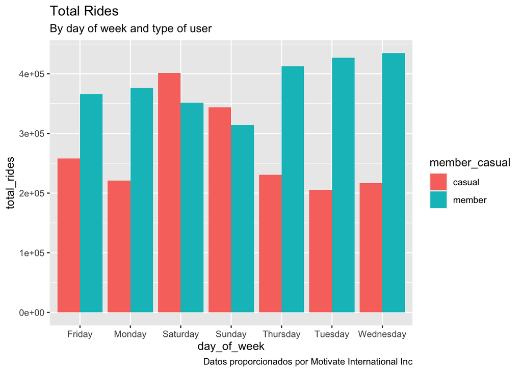

```r
df %>% group_by(member_casual, day_of_week) %>%
  summarise(total_rides = n()) %>%
  arrange(member_casual, day_of_week) %>%
  ggplot(aes(x = day_of_week, y = total_rides, fill = member_casual)) +
  geom_col(position = "dodge") +
  labs(title = "Total Rides") +
  labs(subtitle = "By day of week and type of user") +
  labs(caption = "Datos proporcionados por Motivate International Inc")
```

[output not shown]

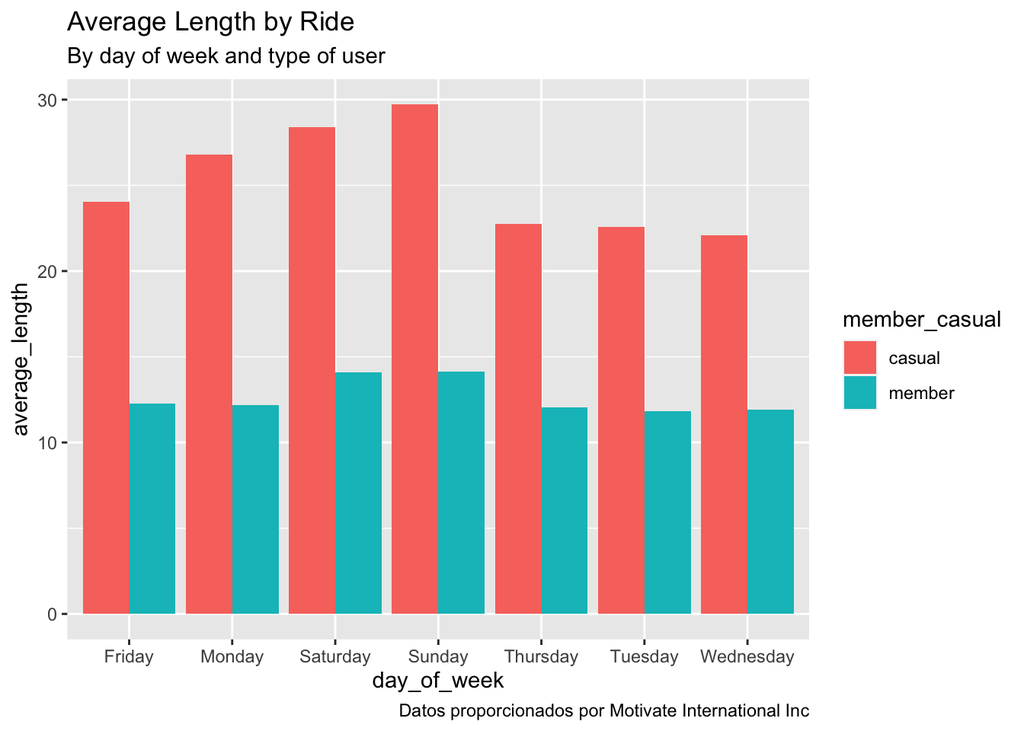

```r
df %>% group_by(member_casual, day_of_week) %>%
  summarise(average_length = mean(ride_length)) %>%
  arrange(member_casual, day_of_week) %>%
  ggplot(aes(x = day_of_week, y = average_length, fill = member_casual)) +
  geom_col(position = "dodge") +
  labs(title = "Average Length by Ride") +
  labs(subtitle = "By day of week and type of user") +
  labs(caption = "Datos proporcionados por Motivate International Inc")
```

#### Visualizaciones realizadas con Tableau en el siguiente [link](https://public.tableau.com/app/profile/fernando.hern.ndez.esquivel/viz/CyclisticDataAnalysis_16633949130300/Dashboard1)

## 6.-ACTUAR

### Las tres recomendaciones más importantes basadas en el análisis

● 1.-La campaña de marketing debe enfocarse en los ciclistas ocasionales que hacen uso de las bicicletas el día sábado y domingo.  
● 2.-La campaña de marketing puede basarse en el tiempo promedio que usan los ciclistas ocasionales para ofrecer algún tipo de beneficio o recompensa.  
● 3.-La campaña de marketing debe enfocarse en presentar mayor publicidad en las estaciones donde se realizan la mayoría de los viajes.